# SQL Query

Using Variance = E[X^2] - E[X]^2

```
SELECT (SUM(SPEND)/COUNT(SPEND)) AS AVG_SPEND,

SQRT((SUM(SPEND^2)/COUNT(SPEND)) - (SUM(SPEND)/COUNT(SPEND))^2) AS SD_SPEND

FROM COHORT_DATA

GROUP BY COHORT;
```

# Reading the Data

```r
census_data <- read.table("census-income.data", sep = ",", header = FALSE)
census_test <- read.table("census-income.test", sep = ",", header = FALSE)
```

```r
names_data <- readLines("census-income.names", enc = 'UTF-8')
fields <- names_data[24:68]
headers <- sub(".*\\t", "", fields)

actual_headers <- headers[-c(5,21,35,40, 42)]

col_names <- c(actual_headers, "YEAR", "Income_Level")

colnames(census_data) <- col_names
colnames(census_test) <- col_names
```

Match column names to descriptions, remove MARSUPWT (instance weights), since it is not to be used as a classifier. Cases that are outside of the universe for a variable are labeled "NIU" - for example, children are not usually asked employment questions.

Check for duplicates and remove them

```r
print(sum(duplicated(census_data)))
print(sum(duplicated(census_test)))

census_data <- unique(census_data)
census_test <- unique(census_test)
```

```
[1] 46627
[1] 20898
```

We look at some of the numeric columns; these need to be converted to nominal factors instead.

```r
nums <- sapply(census_data, is.numeric)
Numeric_Columns <- colnames(census_data[, nums])

Nominal_Columns <- c("ADTIND", "ADTOCC", "SEOTR", "VETYN", "YEAR")

for (each in Nominal_Columns) {
  census_data[[each]] <- as.factor(census_data[[each]])
  census_test[[each]] <- as.factor(census_test[[each]])
}
```

### Exploratory Analysis

We first look at how the response variable is distributed across the training data and test data.

#### Training

```r
print(prop.table(table(census_data$Income_Level)*100))
```

```
  - 50000.    50000+.
0.91911495 0.08088505
```

#### Test

```r
print(prop.table(table(census_test$Income_Level)*100))
```

```
  - 50000.    50000+.
0.92156117 0.07843883
```

For analysis, I split the data into two subsets, one with numeric variables and the other with factor variables.

```r
numeric_census_data <- cbind(census_data[, sapply(census_data, is.numeric)], census_data$Income_Level)
colnames(numeric_census_data)[8] <- c("Income_Level")

nominal_census_data <- census_data[, sapply(census_data, is.factor)]
```

We look at the summary statistics of each of the numeric variables split on Income Level, to get an idea of which ones best discriminate the classification response.

Plot interleaved histograms of each of the numeric variables according to Income Level.

```r
for (i in (1:7)){
  current_variable <- colnames(numeric_census_data)[i]

  assign(paste("table_", current_variable, sep = ""),
         tapply(numeric_census_data[,i], numeric_census_data$Income_Level, summary))

  density_plot <- ggplot(numeric_census_data, aes_string(current_variable, color = "Income_Level")) + geom_histogram(binwidth=.5, alpha=.5, position="identity")

  assign(paste("plot_", current_variable, sep = ""),
         density_plot)

}
```

We look at some of the density plots and summary statistics:

```r
table_AAGE
```

```
$` - 50000.`
   Min. 1st Qu.  Median    Mean 3rd Qu.    Max.
   0.00   24.00   37.00   39.14   52.00   90.00

$` 50000+.`
   Min. 1st Qu.  Median    Mean 3rd Qu.    Max.
  16.00   38.00   45.00   46.27   53.00   90.00
```

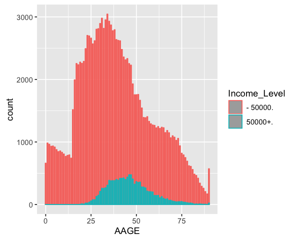

```r
options(repr.plot.width=5, repr.plot.height=4)
plot_AAGE
```

```r
table_CAPGAIN
```

```
$` - 50000.`
    Min.  1st Qu.   Median     Mean  3rd Qu.     Max.
     0.0      0.0      0.0    191.5      0.0 100000.0

$` 50000+.`
   Min. 1st Qu.  Median    Mean 3rd Qu.    Max.
      0       0       0    4837       0  100000
```

```r
table_WKSWORK
```

```
$` - 50000.`
   Min. 1st Qu.  Median    Mean 3rd Qu.    Max.
   0.00    0.00   40.00   28.48   52.00   52.00

$` 50000+.`
   Min. 1st Qu.  Median    Mean 3rd Qu.    Max.
   0.00   52.00   52.00   48.08   52.00   52.00
```

We look at each of the factors and the Income Level in turn

```r
for (i in (1:33)){
  current_variable <- colnames(nominal_census_data)[i]

  tab <-  table(nominal_census_data[,i], nominal_census_data$Income_Level)

  # The code below to generate the tables was taken from StackOverflow
  pt <- percent(c(round(prop.table(tab,2), 3)))
  dim(pt) <- dim(tab)
  dimnames(pt) <- dimnames(tab)
  ## This ends code from StackOverflow

  tab_gg  <- c(round(prop.table(tab,2), 3))
  dim(tab_gg)  <- dim(tab)
  dimnames(tab_gg)  <- dimnames(tab)

  assign(paste("factor_table_", current_variable, sep = ""),
         pt)

  mosaic_plot <- plotluck(as.formula(paste(current_variable, "~", "Income_Level",sep = " ")), data = census_data)

  assign(paste("factor_plot_", current_variable, sep = ""),
         mosaic_plot)
}
```

```
Factor variable ADTIND has too many levels (52), truncating to 30
Factor variable ADTOCC has too many levels (47), truncating to 30
Factor variable GRINST has too many levels (51), truncating to 30
Factor variable HHDFMX has too many levels (36), truncating to 30
Factor variable PEFNTVTY has too many levels (43), truncating to 30
Factor variable PEMNTVTY has too many levels (43), truncating to 30
Factor variable PENATVTY has too many levels (43), truncating to 30
```

```r
print(factor_table_ACLSWKR,quote = FALSE, right = TRUE)
```

```
                                   - 50000.  50000+.
   Federal government                  1.7%     4.8%
   Local government                    4.9%     6.8%
   Never worked                        0.3%     0.0%
   Not in universe                    37.9%     7.3%
   Private                            45.8%    59.2%
   Self-employed-incorporated          1.5%     9.2%
   Self-employed-not incorporated      5.1%     8.8%
   State government                    2.7%     3.9%
   Without pay                         0.1%     0.0%
```

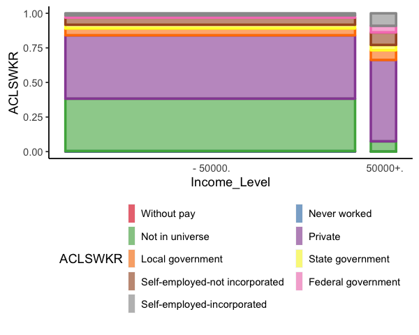

```r
options(repr.plot.width=5, repr.plot.height=4)
factor_plot_ACLSWKR
```

```r
print(factor_table_AHGA,quote = FALSE, right = TRUE)
```

```
                                           - 50000.  50000+.
   10th grade                                  4.6%     0.5%
   11th grade                                  4.4%     0.6%
   12th grade no diploma                       1.4%     0.3%
   1st 2nd 3rd or 4th grade                    1.2%     0.1%
   5th or 6th grade                            2.2%     0.2%
   7th and 8th grade                           4.4%     0.6%
   9th grade                                   3.5%     0.3%
   Associates degree-academic program          2.8%     3.3%
   Associates degree-occup /vocational         3.4%     3.3%
   Bachelors degree(BA AB BS)                 11.0%    31.6%
   Children                                    9.0%     0.0%
   Doctorate degree(PhD EdD)                   0.4%     5.3%
   High school graduate                       29.7%    15.2%
   Less than 1st grade                         0.6%     0.0%
   Masters degree(MA MS MEng MEd MSW MBA)      3.1%    16.4%
   Prof school degree (MD DDS DVM LLB JD)      0.6%     7.8%
   Some college but no degree                 17.5%    14.4%
```

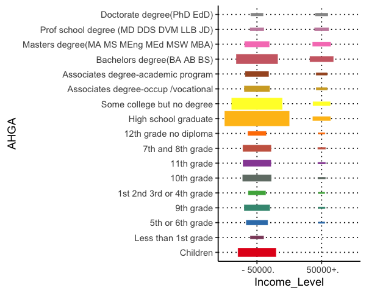

```r
options(repr.plot.width=5, repr.plot.height=4)
factor_plot_AHGA
```

```r
print(factor_table_ASEX,quote = FALSE, right = TRUE)
```

```
           - 50000.  50000+.
   Female     54.1%    21.5%
   Male       45.9%    78.5%
```

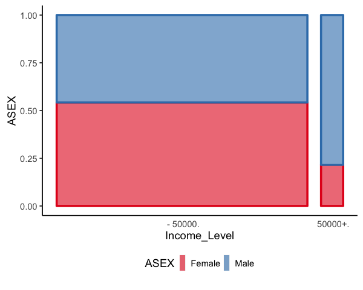

```r
options(repr.plot.width=5, repr.plot.height=4)
factor_plot_ASEX
```

```r
print(factor_table_FILESTAT,quote = FALSE, right = TRUE)
```

```
                                 - 50000.  50000+.
   Head of household                 5.0%     3.6%
   Joint both 65+                    4.3%     3.6%
   Joint both under 65              39.4%    71.5%
   Joint one under 65 & one 65+      2.2%     2.4%
   Nonfiler                         24.7%     0.3%
   Single                           24.4%    18.6%
```

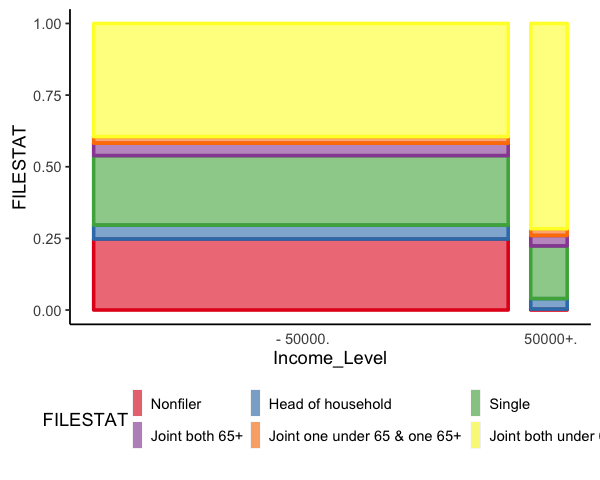

```r
options(repr.plot.width=5, repr.plot.height=4)
factor_plot_FILESTAT
```

### Building a Model

```r
# Make sure levels match between test and training
levels(census_test$HHDFMX) <- levels(census_data$HHDFMX)

#Base probability we need to beat:
print(prop.table(table(census_test$Income_Level)*100))
```

```
  - 50000.    50000+.
0.92156117 0.07843883
```

### Naive-Bayes

- Uses Bayes' rule to calculate posterior probabilities.
- Fast and not sensitive to irrelevant features
- However, it assumes that all variables are independent - likely not true in this case.
- We build a model using all the features.

```r
nb_model <- naiveBayes(Income_Level ~ ., data = census_data)
nb_test_predict <- predict(nb_model,census_test)
```

```r
CrossTable(census_test$Income_Level, nb_test_predict,
           prop.chisq = FALSE, prop.c = FALSE, prop.r = FALSE,
           dnn = c('actual Income', 'predicted Income'))

print(paste("Accuracy is", mean(nb_test_predict==census_test$Income_Level)))
```

```
   Cell Contents
|-------------------------|
|                       N |
|         N / Table Total |
|-------------------------|


Total Observations in Table:  78864


              | predicted Income
actual Income |  - 50000. |   50000+. | Row Total |
--------------|-----------|-----------|-----------|
     - 50000. |     63942 |      8736 |     72678 |
              |     0.811 |     0.111 |           |
--------------|-----------|-----------|-----------|
      50000+. |      1794 |      4392 |      6186 |
              |     0.023 |     0.056 |           |
--------------|-----------|-----------|-----------|
 Column Total |     65736 |     13128 |     78864 |
--------------|-----------|-----------|-----------|


[1] "Accuracy is 0.866479001825928"
```

### C5.0 Decision Tree

- Fast
- C5.0 algorithm uses entropy and information gain
- Categorical variables - Partition by each level and find the best variable with highest information gain.
- Continuous variables - Get the best cut point to do a binary partition with highest information gain.
- You can see which attributes are used the most.

```r
C5tree  <- C5.0(census_data[-41],census_data$Income_Level)

pred_tree  <- predict(C5tree, census_test)
```

```r
CrossTable(census_test$Income_Level, pred_tree,
           prop.chisq = FALSE, prop.c = FALSE, prop.r = FALSE,
           dnn = c('actual Income', 'predicted Income'))

print(paste("Accuracy is", mean(pred_tree==census_test$Income_Level)))
```

```
   Cell Contents
|-------------------------|
|                       N |
|         N / Table Total |
|-------------------------|


Total Observations in Table:  78864


              | predicted Income
actual Income |  - 50000. |   50000+. | Row Total |
--------------|-----------|-----------|-----------|
     - 50000. |     72324 |       354 |     72678 |
              |     0.917 |     0.004 |           |
--------------|-----------|-----------|-----------|
      50000+. |      4731 |      1455 |      6186 |
              |     0.060 |     0.018 |           |
--------------|-----------|-----------|-----------|
 Column Total |     77055 |      1809 |     78864 |
--------------|-----------|-----------|-----------|


[1] "Accuracy is 0.935521911138162"
```

```r
#summary(C5tree)
```

Evaluation on training data (152896 cases):

```
    Decision Tree
  ----------------
  Size      Errors

   293 8211( 5.4%)   <<


    (a)    (b)    <-classified as
  -----  -----
 138990   1539    (a): class - 50000.
   6672   5695    (b): class 50000+.
```

Attribute usage:

```
100.00%    CAPGAIN
 97.83%    CAPLOSS
 96.32%    AHGA
 95.23%    DIVVAL
 88.60%    AHRSPAY
 25.78%    ADTOCC
 11.17%    ASEX
  9.70%    AAGE
  9.35%    WKSWORK
  5.60%    HHDFMX
  3.97%    FILESTAT
  3.61%    NOEMP
  2.85%    AMARITL
  2.24%    AUNTYPE
  1.55%    AHSCOL
  1.21%    PARENT
  0.95%    ADTIND
  0.81%    VETYN
  0.79%    ARACE
  0.76%    VETQVA
  0.62%    PEMNTVTY
  0.48%    ACLSWKR
  0.40%    AREORGN
  0.32%    GRINREG
  0.25%    HHDREL
  0.10%    PEFNTVTY
  0.10%    AMJOCC
  0.09%    AUNMEM
  0.07%    AWKSTAT
  0.06%    SEOTR
  0.01%    MIGSAME
  0.01%    PRCITSHP
```

### Improvements:

- Explore NBTree; no pure R package (in Java)
- Research more about feature selection for classification
- Build models on smaller subsets, selecting important features
- Look at other measures to assess models, other than misclassification/error rate.